# TP2: Extensions to linear models — Correction

Author

Lionel Hertzog

Published

September 11, 2026

```r
library(tidyverse)
library(DHARMa)
library(ggeffects)
```

## 1 Objectives

The aim of this practical is to explore several extensions of the linear model:

1. Multiple covariates
2. Interactions
3. Variable transformations
4. Polynomial terms

We continue working with forest biomass data from the Vosges, using an augmented dataset containing information on stand structure, elevation, soil properties, dominant tree species and ownership.

## 2 Read the data

We first load the dataset and perform a quick exploration.

```r
here::i_am("practicals/tp2_correction.qmd")

dat <- read.csv("../data/dat_tp2.csv")

head(dat)
```

```
     idp       mqd   biomass  zp reserutile troph_r       species
1 746162 0.3446880 348.55178 332       89.5 2.98077 Pin sylvestre
2 712867 0.2135135 238.30077 348       63.0 1.11424 Sapin pectiné
3 720620 0.2213249 134.87458 359       35.0 4.04955 Sapin pectiné
4 770767 0.1574642 117.60808 374       50.4 1.18779       Douglas
5 751199 0.3101397  74.84114 466       21.0 2.37592 Sapin pectiné
6 740332 0.2938409 249.62688 384       29.4 1.19309 Sapin pectiné
                            ownership
1                Forêts domaniales RF
2          Autres forêts publiques RF
3 Forêts privées et autres - Hors PSG
4   Forêts privées et autres - En PSG
5                Forêts domaniales RF
6   Forêts privées et autres - En PSG
```

```r
str(dat)
```

```
'data.frame':   3579 obs. of  8 variables:
 $ idp       : int  746162 712867 720620 770767 751199 740332 701937 750486 758280 772844 ...
 $ mqd       : num  0.345 0.214 0.221 0.157 0.31 ...
 $ biomass   : num  348.6 238.3 134.9 117.6 74.8 ...
 $ zp        : int  332 348 359 374 466 384 445 507 295 417 ...
 $ reserutile: num  89.5 63 35 50.4 21 ...
 $ troph_r   : num  2.98 1.11 4.05 1.19 2.38 ...
 $ species   : chr  "Pin sylvestre" "Sapin pectiné" "Sapin pectiné" "Douglas" ...
 $ ownership : chr  "Forêts domaniales RF" "Autres forêts publiques RF" "Forêts privées et autres - Hors PSG" "Forêts privées et autres - En PSG" ...
```

```r
summary(dat)
```

```
      idp               mqd             biomass               zp
 Min.   :    127   Min.   :0.07639   Min.   :   0.498   Min.   : 185.0
 1st Qu.: 473917   1st Qu.:0.19177   1st Qu.: 135.113   1st Qu.: 403.0
 Median : 972456   Median :0.25831   Median : 223.044   Median : 559.0
 Mean   :1001500   Mean   :0.27409   Mean   : 232.211   Mean   : 585.3
 3rd Qu.:1531706   3rd Qu.:0.33730   3rd Qu.: 313.977   3rd Qu.: 741.0
 Max.   :2054819   Max.   :0.75587   Max.   :1113.858   Max.   :1290.0
                                     NA's   :169
   reserutile        troph_r         species           ownership
 Min.   :  0.00   Min.   :0.2541   Length:3579        Length:3579
 1st Qu.: 34.80   1st Qu.:1.6669   Class :character   Class :character
 Median : 54.60   Median :2.4090   Mode  :character   Mode  :character
 Mean   : 58.85   Mean   :2.7922
 3rd Qu.: 78.00   3rd Qu.:3.5615
 Max.   :175.50   Max.   :8.7918
                  NA's   :4
```

```r
colSums(is.na(dat))
```

```
       idp        mqd    biomass         zp reserutile    troph_r    species
         0          0        169          0          0          4          0
 ownership
         0
```

The variables are:

- `idp`: plot ID
- `mqd`: square root of the mean quadratic diameter, a proxy for stand maturity, in m
- `biomass`: above- and belowground tree biomass, in tonnes of dry matter per hectare
- `zp`: elevation, in m
- `reserutile`: soil water-holding capacity, in mm
- `troph_r`: soil fertility proxy derived from the flora, ranging from 0 (acid soils) to 11 (calcareous soils)
- `species`: dominant tree species
- `ownership`: ownership status of the plot

There are some missing values in `biomass` and `troph_r`. For the regression analyses, we use complete observations for the variables included in each model.

A useful first look at the main numerical variables is:

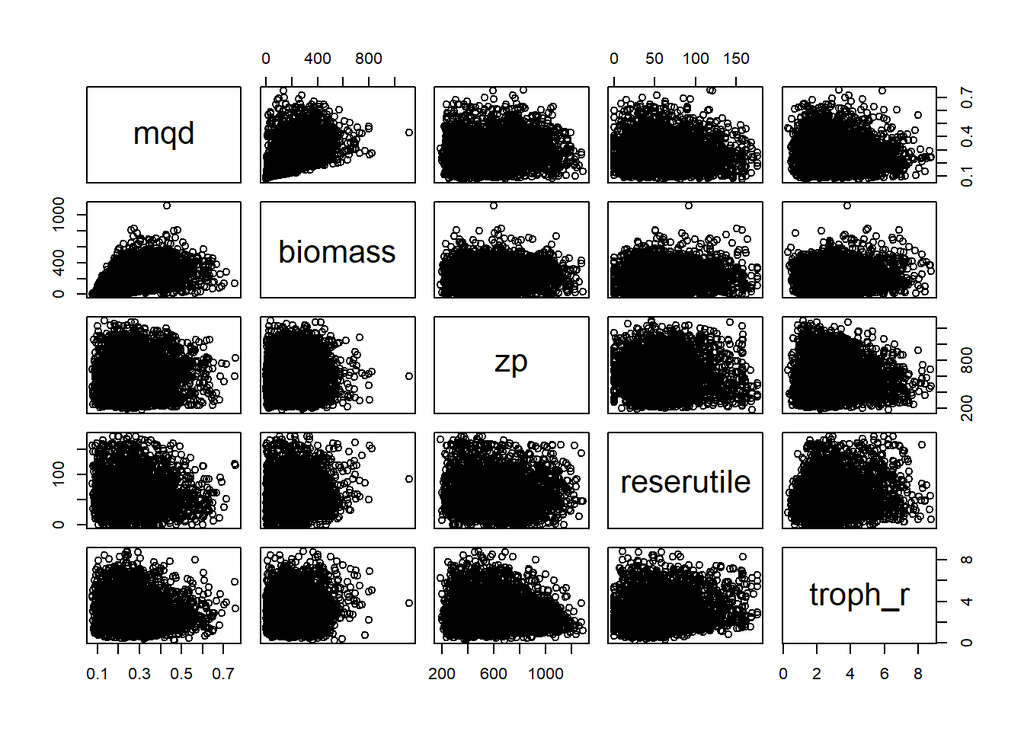

```r
dat %>%
  select(mqd, biomass, zp, reserutile, troph_r) %>%
  pairs()
```

## 3 Multiple covariates

### 3.1 1.1 Fit a model with several covariates

We first model biomass as a function of soil fertility, soil water-holding capacity and elevation:

$$biomass =
\beta_0 +
\beta_1 troph_r +
\beta_2 reserutile +
\beta_3 zp +
\epsilon.$$

```r
# drop na for the needed covariables
dat_m1 <- dat %>%
  drop_na(biomass, troph_r, reserutile, zp)

# fit the model
m1 <- lm(
  biomass ~ troph_r + reserutile + zp,
  data = dat_m1
)

summary(m1)
```

```
Call:
lm(formula = biomass ~ troph_r + reserutile + zp, data = dat_m1)

Residuals:
    Min      1Q  Median      3Q     Max
-285.28  -94.88   -5.79   83.07  864.65

Coefficients:
             Estimate Std. Error t value Pr(>|t|)
(Intercept) 1.661e+02  8.296e+00  20.017  < 2e-16 ***
troph_r     1.366e+01  1.502e+00   9.093  < 2e-16 ***
reserutile  8.785e-02  6.791e-02   1.294    0.196
zp          3.907e-02  9.989e-03   3.911 9.35e-05 ***
---
Signif. codes:  0 '***' 0.001 '**' 0.01 '*' 0.05 '.' 0.1 ' ' 1

Residual standard error: 130.8 on 3402 degrees of freedom
Multiple R-squared:  0.02945,   Adjusted R-squared:  0.02859
F-statistic: 34.41 on 3 and 3402 DF,  p-value: < 2.2e-16
```

We then check the model assumptions with DHARMa:

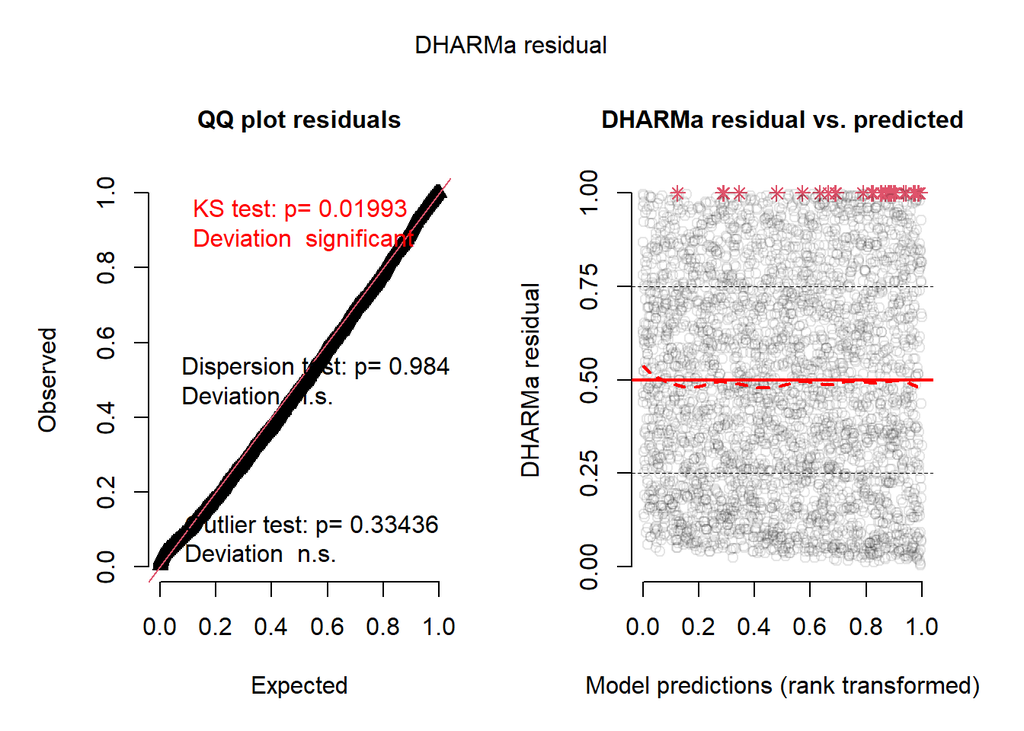

```r
res1 <- simulateResiduals(m1)

plot(res1)
```

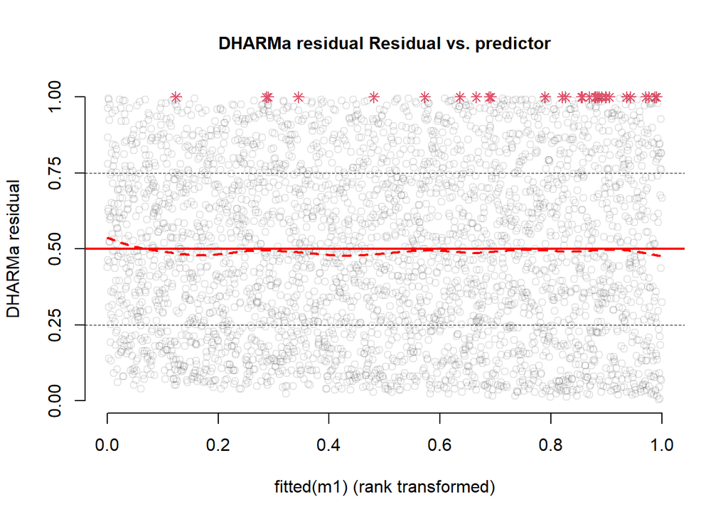

```r
plotResiduals(res1, form = fitted(m1))
```

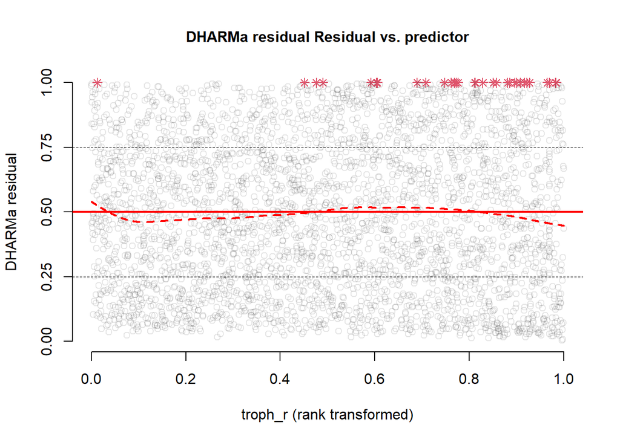

```r
plotResiduals(res1, form = dat_m1$troph_r) # this is testing the linearity of the relation
```

**Interpretation.**

The model explains only a relatively small proportion (3%) of the variation in biomass. The diagnostic plots should nevertheless be inspected before interpreting the coefficients.

The important point is that adding several covariates does not automatically make a model useful: we need to consider both the estimated effects and whether the model describes the data adequately.

### 3.2 1.2 Can we identify the most important covariate?

The raw regression coefficients cannot be directly compared because the three covariates are measured in very different units.

For example, `troph_r` is an index, `reserutile` is measured in mm, and `zp` is measured in metres.

A simple solution is to standardise the predictors before fitting the model:

```r
m1_scaled <- lm(
  biomass ~ scale(troph_r) +
    scale(reserutile) +
    scale(zp),
  data = dat_m1
)

summary(m1_scaled)
```

```
Call:
lm(formula = biomass ~ scale(troph_r) + scale(reserutile) + scale(zp),
    data = dat_m1)

Residuals:
    Min      1Q  Median      3Q     Max
-285.28  -94.88   -5.79   83.07  864.65

Coefficients:
                  Estimate Std. Error t value Pr(>|t|)
(Intercept)        232.238      2.241 103.653  < 2e-16 ***
scale(troph_r)      20.627      2.269   9.093  < 2e-16 ***
scale(reserutile)    2.933      2.267   1.294    0.196
scale(zp)            8.769      2.242   3.911 9.35e-05 ***
---
Signif. codes:  0 '***' 0.001 '**' 0.01 '*' 0.05 '.' 0.1 ' ' 1

Residual standard error: 130.8 on 3402 degrees of freedom
Multiple R-squared:  0.02945,   Adjusted R-squared:  0.02859
F-statistic: 34.41 on 3 and 3402 DF,  p-value: < 2.2e-16
```

The coefficients now correspond to a one-standard-deviation increase in each predictor.

For this dataset, the standardised coefficients show that **soil fertility (`troph_r`) has the largest estimated effect**, followed by elevation (`zp`), while the effect of water-holding capacity (`reserutile`) is considerably smaller.

We should, however, avoid interpreting coefficient magnitude alone as a complete measure of variable importance. Statistical uncertainty, ecological relevance and the amount of independent information provided by each variable also matter.

### 3.3 1.3 Effects of soil fertility under different environmental conditions

We can use `predict_response()` to visualise the expected biomass across the soil-fertility gradient while changing the values of the other covariates.

Here we use the mean ± one standard deviation as representative values:

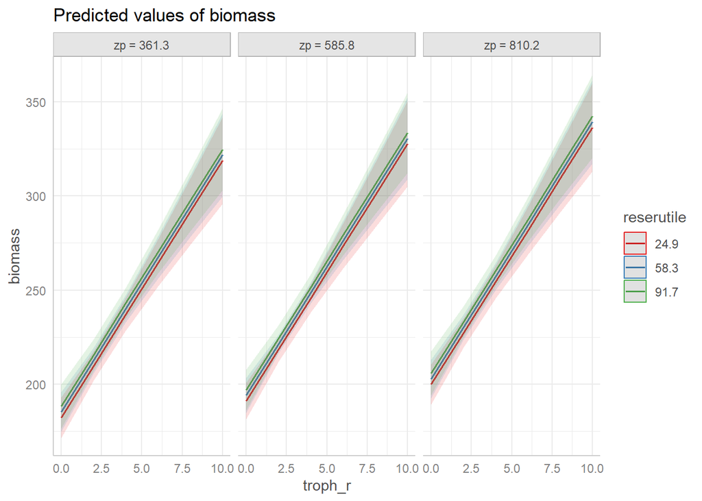

```r
reserutile_values <- with(
  dat_m1,
  mean(reserutile) + c(-1, 0, 1) * sd(reserutile)
)

zp_values <- with(
  dat_m1,
  mean(zp) + c(-1, 0, 1) * sd(zp)
)

terms_reserutile <- paste0(
  "reserutile [",
  paste(round(reserutile_values, 1), collapse = ","),
  "]"
)

terms_zp <- paste0(
  "zp [",
  paste(round(zp_values, 1), collapse = ","),
  "]"
)

pred_m1 <- predict_response(
  m1,
  terms = c("troph_r", terms_reserutile, terms_zp)
)

plot(pred_m1)
```

Because this model contains **no interaction terms**, the effect of `troph_r` is additive: changing `reserutile` or `zp` shifts the predicted biomass but does not change the slope of the relationship between biomass and `troph_r` (parallel lines).

## 4 Categorical covariates

### 4.1 2.1 Soil fertility and ownership

We now include ownership as a categorical covariate:

```r
dat_m2 <- dat %>%
  drop_na(biomass, troph_r, ownership)

m2 <- lm(
  biomass ~ troph_r + ownership,
  data = dat_m2
)

summary(m2)
```

```
Call:
lm(formula = biomass ~ troph_r + ownership, data = dat_m2)

Residuals:
    Min      1Q  Median      3Q     Max
-282.86  -96.28   -6.15   83.19  879.80

Coefficients:
                                             Estimate Std. Error t value
(Intercept)                                  197.8119     5.8160  34.012
troph_r                                       14.6829     1.5753   9.321
ownershipForêts domaniales RF                 -6.9726     5.5650  -1.253
ownershipForêts privées et autres - En PSG    -0.8169     8.4170  -0.097
ownershipForêts privées et autres - Hors PSG -19.3356     6.0348  -3.204
                                             Pr(>|t|)
(Intercept)                                   < 2e-16 ***
troph_r                                       < 2e-16 ***
ownershipForêts domaniales RF                 0.21032
ownershipForêts privées et autres - En PSG    0.92269
ownershipForêts privées et autres - Hors PSG  0.00137 **
---
Signif. codes:  0 '***' 0.001 '**' 0.01 '*' 0.05 '.' 0.1 ' ' 1

Residual standard error: 130.9 on 3401 degrees of freedom
Multiple R-squared:  0.0277,    Adjusted R-squared:  0.02656
F-statistic: 24.23 on 4 and 3401 DF,  p-value: < 2.2e-16
```

By default, R uses one ownership class as the reference level. We can see the current ordering with:

```r
levels(factor(dat_m2$ownership))
```

```
[1] "Autres forêts publiques RF"          "Forêts domaniales RF"
[3] "Forêts privées et autres - En PSG"   "Forêts privées et autres - Hors PSG"
```

It is often preferable to choose the reference level explicitly:

```r
dat_m2$ownership <- factor(
  dat_m2$ownership,
  levels = c(
    "Autres forêts publiques RF",
    "Forêts domaniales RF",
    "Forêts privées et autres - En PSG",
    "Forêts privées et autres - Hors PSG"
  )
)

m2 <- lm(
  biomass ~ troph_r + ownership,
  data = dat_m2
)

summary(m2)
```

```
Call:
lm(formula = biomass ~ troph_r + ownership, data = dat_m2)

Residuals:
    Min      1Q  Median      3Q     Max
-282.86  -96.28   -6.15   83.19  879.80

Coefficients:
                                             Estimate Std. Error t value
(Intercept)                                  197.8119     5.8160  34.012
troph_r                                       14.6829     1.5753   9.321
ownershipForêts domaniales RF                 -6.9726     5.5650  -1.253
ownershipForêts privées et autres - En PSG    -0.8169     8.4170  -0.097
ownershipForêts privées et autres - Hors PSG -19.3356     6.0348  -3.204
                                             Pr(>|t|)
(Intercept)                                   < 2e-16 ***
troph_r                                       < 2e-16 ***
ownershipForêts domaniales RF                 0.21032
ownershipForêts privées et autres - En PSG    0.92269
ownershipForêts privées et autres - Hors PSG  0.00137 **
---
Signif. codes:  0 '***' 0.001 '**' 0.01 '*' 0.05 '.' 0.1 ' ' 1

Residual standard error: 130.9 on 3401 degrees of freedom
Multiple R-squared:  0.0277,    Adjusted R-squared:  0.02656
F-statistic: 24.23 on 4 and 3401 DF,  p-value: < 2.2e-16
```

The model coefficients are interpreted relative to the reference ownership class.

The coefficient for `troph_r` represents the expected change in biomass for a one-unit increase in soil fertility **while holding ownership constant**.

Each ownership coefficient represents the difference in expected biomass between that ownership class and the reference class, **at the same value of `troph_r`**.

For example, the coefficient for `Forêts domaniales RF` is the difference between state forests and the reference ownership class after accounting for soil fertility.

Importantly, this model does **not** allow the effect of soil fertility to differ among ownership classes. It assumes parallel regression lines.

### 4.2 2.2 Plot the predicted values

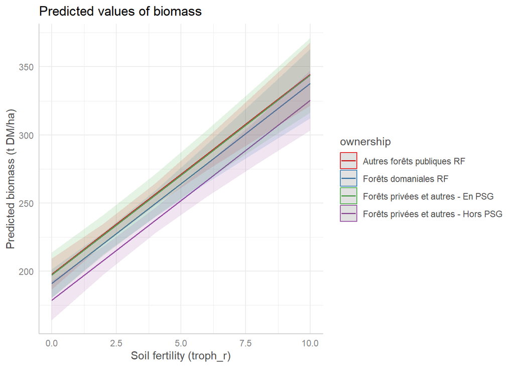

```r
pred_m2 <- predict_response(
  m2,
  terms = c("troph_r", "ownership")
)

plot(pred_m2) +
  labs(
    x = "Soil fertility (troph_r)",
    y = "Predicted biomass (t DM/ha)"
  )
```

The four lines are parallel because the model contains no interaction between `troph_r` and `ownership`.

### 4.3 2.3 Bonus: changing contrasts

The choice of contrasts changes the **parameterisation** of the model, but not the fitted values.

For example, we can use treatment contrasts:

```r
options(contrasts = c("contr.treatment", "contr.poly"))

m2_treatment <- lm(
  biomass ~ troph_r + ownership,
  data = dat_m2
)

coef(m2_treatment)
```

```
                                 (Intercept)
                                 197.8119206
                                     troph_r
                                  14.6829219
               ownershipForêts domaniales RF
                                  -6.9726114
  ownershipForêts privées et autres - En PSG
                                  -0.8168649
ownershipForêts privées et autres - Hors PSG
                                 -19.3355904
```

We can instead use sum contrasts:

```r
options(contrasts = c("contr.sum", "contr.poly"))

m2_sum <- lm(
  biomass ~ troph_r + ownership,
  data = dat_m2
)

coef(m2_sum)
```

```
(Intercept)     troph_r  ownership1  ownership2  ownership3
191.0306539  14.6829219   6.7812667  -0.1913447   5.9644018
```

The numerical values of the coefficients change because their interpretation changes.

With treatment contrasts, the intercept corresponds to the reference ownership class.

With sum contrasts, the intercept corresponds to the grand mean across ownership levels (for a balanced interpretation of the factor), and the factor coefficients describe deviations from that overall mean.

The important result is:

```r
predict(m2_treatment)[1:5]
```

```
       1        2        3        4        5
234.6057 214.1722 237.9356 214.4353 225.7248
```

```r
predict(m2_sum)[1:5]
```

```
       1        2        3        4        5
234.6057 214.1722 237.9356 214.4353 225.7248
```

The predictions are the same (up to numerical precision).

After this exercise, it is good practice to restore the default contrast settings:

```r
options(contrasts = c("contr.treatment", "contr.poly"))
```

## 5 Interactions

An interaction allows the effect of one predictor to depend on another predictor.

### 5.1 1.1 Interaction between soil fertility and ownership

We now fit:

```r
m3 <- lm(
  biomass ~ troph_r * ownership,
  data = dat_m2
)

summary(m3)
```

```
Call:
lm(formula = biomass ~ troph_r * ownership, data = dat_m2)

Residuals:
    Min      1Q  Median      3Q     Max
-284.44  -96.40   -6.24   82.92  880.54

Coefficients:
                                                     Estimate Std. Error
(Intercept)                                           196.537      8.072
troph_r                                                15.125      2.501
ownershipForêts domaniales RF                         -13.324     11.936
ownershipForêts privées et autres - En PSG             -4.754     17.466
ownershipForêts privées et autres - Hors PSG           -6.581     13.603
troph_r:ownershipForêts domaniales RF                   3.040      4.349
troph_r:ownershipForêts privées et autres - En PSG      1.629      5.923
troph_r:ownershipForêts privées et autres - Hors PSG   -3.670      3.740
                                                     t value Pr(>|t|)
(Intercept)                                           24.348  < 2e-16 ***
troph_r                                                6.049 1.62e-09 ***
ownershipForêts domaniales RF                         -1.116    0.264
ownershipForêts privées et autres - En PSG            -0.272    0.786
ownershipForêts privées et autres - Hors PSG          -0.484    0.629
troph_r:ownershipForêts domaniales RF                  0.699    0.485
troph_r:ownershipForêts privées et autres - En PSG     0.275    0.783
troph_r:ownershipForêts privées et autres - Hors PSG  -0.981    0.326
---
Signif. codes:  0 '***' 0.001 '**' 0.01 '*' 0.05 '.' 0.1 ' ' 1

Residual standard error: 130.9 on 3398 degrees of freedom
Multiple R-squared:  0.02842,   Adjusted R-squared:  0.02641
F-statistic:  14.2 on 7 and 3398 DF,  p-value: < 2.2e-16
```

The `*` notation is equivalent to:

```r
biomass ~ troph_r + ownership + troph_r:ownership
```

The interaction coefficients describe how the slope of `troph_r` changes for each ownership class relative to the reference class.

For the reference ownership class:

- the intercept is the expected biomass when `troph_r = 0`;
- the `troph_r` coefficient is the slope of biomass against soil fertility.

For another ownership class:

- its ownership coefficient changes the intercept;
- its interaction coefficient changes the slope.

Thus, for an ownership class with interaction coefficient $\gamma$, its soil-fertility slope is:

$$(\beta_1 + \gamma) * troph\_r$$

For this dataset, the estimated interaction terms are relatively small compared with the main effect of soil fertility. Their is therefore limited evidence for strong interactive effects between ownership class and soil fertility.

### 5.2 1.2 Plot the regression lines

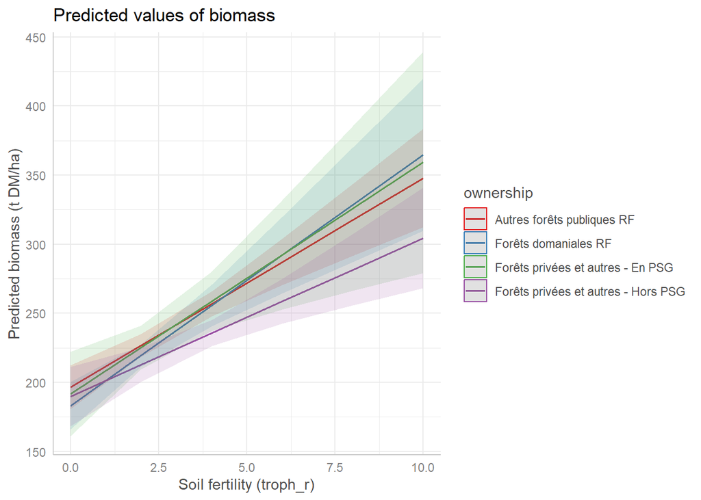

```r
pred_m3 <- predict_response(
  m3,
  terms = c("troph_r", "ownership")
)

plot(pred_m3) +
  labs(
    x = "Soil fertility (troph_r)",
    y = "Predicted biomass (t DM/ha)"
  )
```

Unlike the previous model, the lines are now allowed to have different slopes.

This is the key visual distinction between an additive model and an interaction model:

- **without interaction:** parallel lines;
- **with interaction:** slopes can differ.

## 6 Scaling and interactions

### 6.1 2.1 Scale soil fertility

We now standardise `troph_r` and fit the same interaction model:

```r
m3_scaled <- lm(
  biomass ~ scale(troph_r) * ownership,
  data = dat_m2
)

summary(m3_scaled)
```

```
Call:
lm(formula = biomass ~ scale(troph_r) * ownership, data = dat_m2)

Residuals:
    Min      1Q  Median      3Q     Max
-284.44  -96.40   -6.24   82.92  880.54

Coefficients:
                                                            Estimate Std. Error
(Intercept)                                                 238.7922     3.6416
scale(troph_r)                                               22.8424     3.7763
ownershipForêts domaniales RF                                -4.8318     5.8693
ownershipForêts privées et autres - En PSG                   -0.2039     8.5315
ownershipForêts privées et autres - Hors PSG                -16.8338     6.3123
scale(troph_r):ownershipForêts domaniales RF                  4.5906     6.5686
scale(troph_r):ownershipForêts privées et autres - En PSG     2.4596     8.9453
scale(troph_r):ownershipForêts privées et autres - Hors PSG  -5.5425     5.6476
                                                            t value Pr(>|t|)
(Intercept)                                                  65.573  < 2e-16
scale(troph_r)                                                6.049 1.62e-09
ownershipForêts domaniales RF                                -0.823  0.41044
ownershipForêts privées et autres - En PSG                   -0.024  0.98094
ownershipForêts privées et autres - Hors PSG                 -2.667  0.00769
scale(troph_r):ownershipForêts domaniales RF                  0.699  0.48468
scale(troph_r):ownershipForêts privées et autres - En PSG     0.275  0.78337
scale(troph_r):ownershipForêts privées et autres - Hors PSG  -0.981  0.32647

(Intercept)                                                 ***
scale(troph_r)                                              ***
ownershipForêts domaniales RF
ownershipForêts privées et autres - En PSG
ownershipForêts privées et autres - Hors PSG                **
scale(troph_r):ownershipForêts domaniales RF
scale(troph_r):ownershipForêts privées et autres - En PSG
scale(troph_r):ownershipForêts privées et autres - Hors PSG
---
Signif. codes:  0 '***' 0.001 '**' 0.01 '*' 0.05 '.' 0.1 ' ' 1

Residual standard error: 130.9 on 3398 degrees of freedom
Multiple R-squared:  0.02842,   Adjusted R-squared:  0.02641
F-statistic:  14.2 on 7 and 3398 DF,  p-value: < 2.2e-16
```

The coefficients are different because `scale(troph_r)` changes the units of the predictor.

However, the underlying fitted model is the same apart from the change of units. In particular, the fitted values are identical:

```r
all.equal(
  fitted(m3),
  fitted(m3_scaled),
  tolerance = 1e-8
)
```

```
[1] TRUE
```

Scaling changes the interpretation of the coefficients, but not the information contained in the predictor or the fitted relationship.

### 6.2 2.2 Interaction between soil fertility and elevation

We now consider whether the relationship between soil fertility and biomass changes with elevation.

First, fit the model using the original soil-fertility variable:

```r
dat_m4 <- dat %>%
  drop_na(biomass, troph_r, zp)

m4 <- lm(
  biomass ~ troph_r * zp,
  data = dat_m4
)

summary(m4)
```

```
Call:
lm(formula = biomass ~ troph_r * zp, data = dat_m4)

Residuals:
    Min      1Q  Median      3Q     Max
-298.65  -95.07   -5.31   82.66  864.92

Coefficients:
              Estimate Std. Error t value Pr(>|t|)
(Intercept) 234.211403  13.229907  17.703  < 2e-16 ***
troph_r     -10.630366   4.429061  -2.400 0.016442 *
zp           -0.074846   0.021756  -3.440 0.000588 ***
troph_r:zp    0.044010   0.007474   5.888 4.28e-09 ***
---
Signif. codes:  0 '***' 0.001 '**' 0.01 '*' 0.05 '.' 0.1 ' ' 1

Residual standard error: 130.1 on 3402 degrees of freedom
Multiple R-squared:  0.03877,   Adjusted R-squared:  0.03792
F-statistic: 45.74 on 3 and 3402 DF,  p-value: < 2.2e-16
```

Then fit the same model after standardising the variables:

```r
m4_scaled <- lm(
  biomass ~ scale(troph_r) * scale(zp),
  data = dat_m4
)

summary(m4_scaled)
```

```
Call:
lm(formula = biomass ~ scale(troph_r) * scale(zp), data = dat_m4)

Residuals:
    Min      1Q  Median      3Q     Max
-298.65  -95.07   -5.31   82.66  864.92

Coefficients:
                         Estimate Std. Error t value Pr(>|t|)
(Intercept)               232.692      2.231 104.296  < 2e-16 ***
scale(troph_r)             22.880      2.252  10.160  < 2e-16 ***
scale(zp)                  10.797      2.257   4.783 1.80e-06 ***
scale(troph_r):scale(zp)   14.918      2.533   5.888 4.28e-09 ***
---
Signif. codes:  0 '***' 0.001 '**' 0.01 '*' 0.05 '.' 0.1 ' ' 1

Residual standard error: 130.1 on 3402 degrees of freedom
Multiple R-squared:  0.03877,   Adjusted R-squared:  0.03792
F-statistic: 45.74 on 3 and 3402 DF,  p-value: < 2.2e-16
```

The coefficients are not numerically identical because the unit of `troph_r` has changed.

For example, in the unscaled model, the interaction coefficient describes the change in the effect of one **unit** of `troph_r` associated with a one-metre increase in elevation.

After scaling, it describes the change in the effect of a **one-standard-deviation** increase in `troph_r` associated with a **one-standard-deviation** increase in elevation.

The fitted values, residuals and model fit are unchanged:

```r
all.equal(
  fitted(m4),
  fitted(m4_scaled),
  tolerance = 1e-8
)
```

```
[1] TRUE
```

This illustrates an important property of scaling: **it changes the parameterisation and interpretation of coefficients, but not the fitted relationship.**

Scaling can nevertheless be very useful when interaction terms are present because it makes the main effects more interpretable and can reduce numerical problems when predictors are on very different scales.

## 7 Non-linear relations

Linear models can describe some non-linear relationships by transforming predictors or by adding polynomial terms.

### 7.1 Variable transformation

The relationship between biomass and elevation can be explored with a smooth curve:

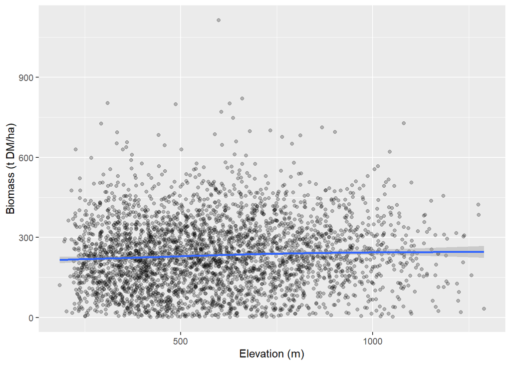

```r
ggplot(dat, aes(x = zp, y = biomass)) +
  geom_point(alpha = 0.25) +
  stat_smooth() +
  labs(
    x = "Elevation (m)",
    y = "Biomass (t DM/ha)"
  )
```

### 7.2 1. Which transformation is appropriate?

A saturating relationship is naturally represented by a logarithmic transformation:

$$biomass = \beta_0 + \beta_1 \log(zp) + \epsilon.$$

The logarithm increases rapidly at low values of `zp` and progressively more slowly as `zp` increases, producing a saturating curve when expressed against the original elevation scale.

We can compare several possibilities visually:

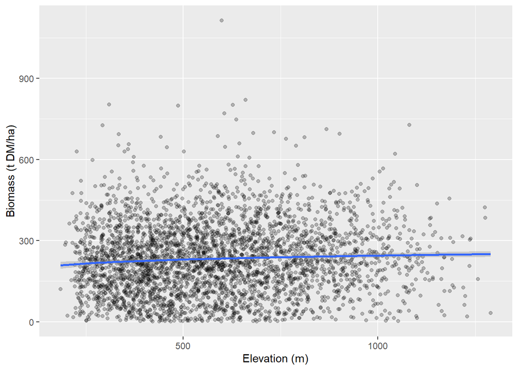

```r
ggplot(dat, aes(x = zp, y = biomass)) +
  geom_point(alpha = 0.25) +
  stat_smooth(
    method = "lm",
    formula = y ~ log(x)
  ) +
  labs(
    x = "Elevation (m)",
    y = "Biomass (t DM/ha)"
  )
```

The logarithmic transformation is therefore a sensible choice here.

### 7.3 2. Fit the transformed model

We can fit the model directly in the formula:

```r
dat_m5 <- dat %>%
  drop_na(biomass, zp)

m_log_zp <- lm(
  biomass ~ log(zp),
  data = dat_m5
)

summary(m_log_zp)
```

```
Call:
lm(formula = biomass ~ log(zp), data = dat_m5)

Residuals:
    Min      1Q  Median      3Q     Max
-243.60  -95.03   -9.71   81.88  879.57

Coefficients:
            Estimate Std. Error t value Pr(>|t|)
(Intercept)   98.714     35.934   2.747  0.00604 **
log(zp)       21.200      5.695   3.722  0.00020 ***
---
Signif. codes:  0 '***' 0.001 '**' 0.01 '*' 0.05 '.' 0.1 ' ' 1

Residual standard error: 132.4 on 3408 degrees of freedom
Multiple R-squared:  0.004049,  Adjusted R-squared:  0.003757
F-statistic: 13.86 on 1 and 3408 DF,  p-value: 0.0002005
```

For comparison, fit the untransformed model:

```r
m_linear_zp <- lm(
  biomass ~ zp,
  data = dat_m5
)

summary(m_linear_zp)
```

```
Call:
lm(formula = biomass ~ zp, data = dat_m5)

Residuals:
    Min      1Q  Median      3Q     Max
-246.45  -94.89   -9.24   82.21  881.18

Coefficients:
            Estimate Std. Error t value Pr(>|t|)
(Intercept) 210.9950     6.3384  33.288  < 2e-16 ***
zp            0.0362     0.0101   3.584 0.000343 ***
---
Signif. codes:  0 '***' 0.001 '**' 0.01 '*' 0.05 '.' 0.1 ' ' 1

Residual standard error: 132.4 on 3408 degrees of freedom
Multiple R-squared:  0.003756,  Adjusted R-squared:  0.003463
F-statistic: 12.85 on 1 and 3408 DF,  p-value: 0.0003426
```

### 7.4 3. Plot and compare the fitted relationships

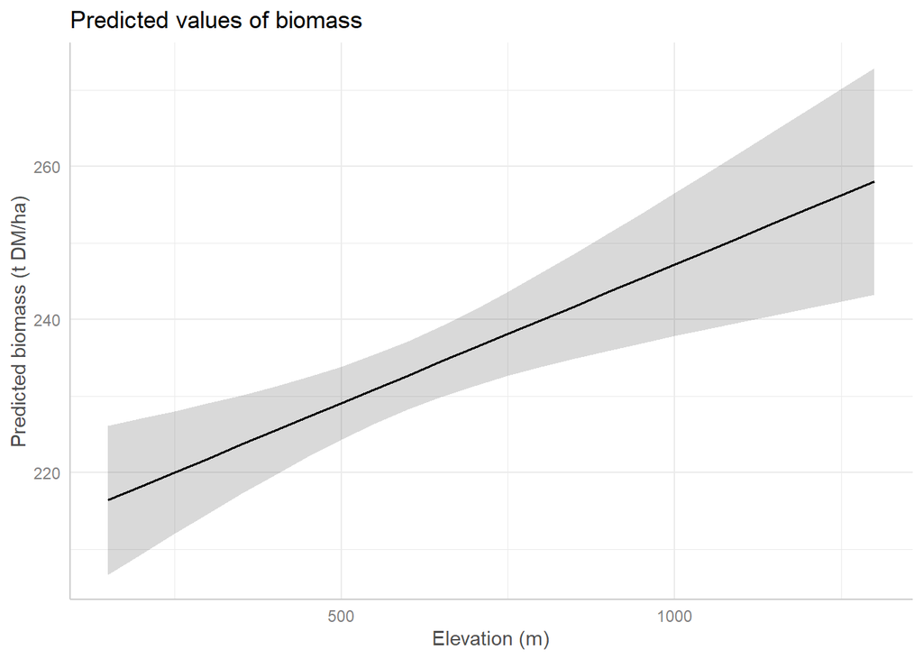

```r
pred_linear_zp <- predict_response(
  m_linear_zp,
  terms = "zp"
)

pred_log_zp <- predict_response(
  m_log_zp,
  terms = "zp"
)

plot(pred_linear_zp) +
  labs(
    x = "Elevation (m)",
    y = "Predicted biomass (t DM/ha)"
  )
```

and:

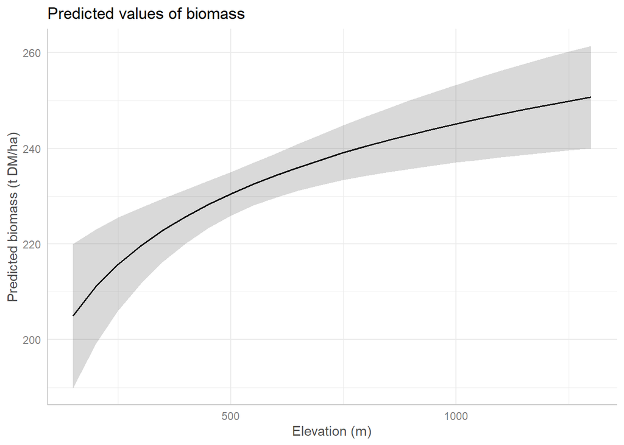

```r
plot(pred_log_zp) +
  labs(
    x = "Elevation (m)",
    y = "Predicted biomass (t DM/ha)"
  )
```

The logarithmic model produces a curve whose slope decreases with elevation, whereas the untransformed model produces a straight line.

## 8 Polynomials

The relationship between stand maturity (`mqd`) and biomass appears hump-shaped:

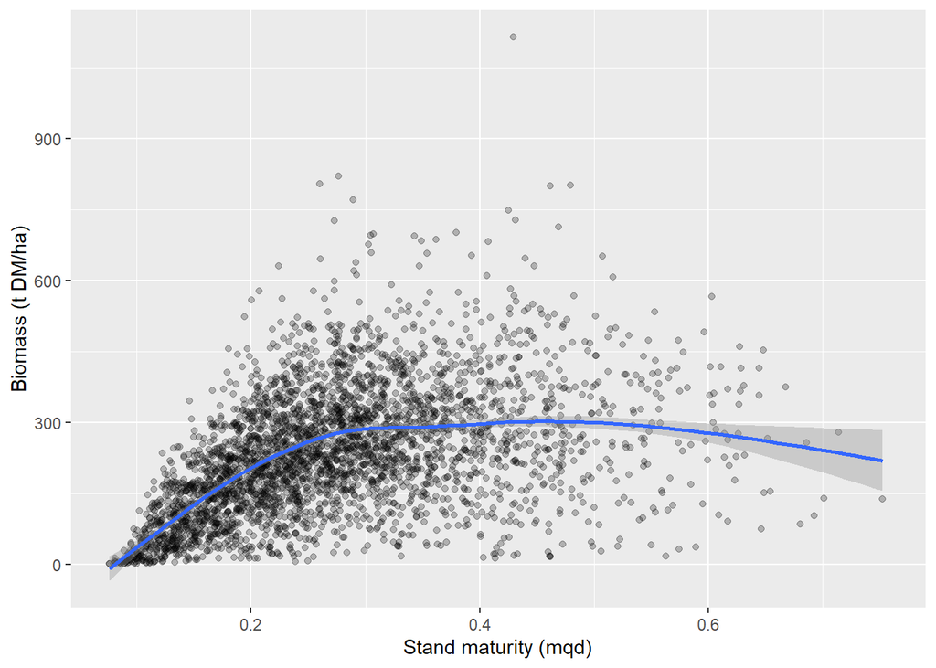

```r
ggplot(dat, aes(x = mqd, y = biomass)) +
  geom_point(alpha = 0.25) +
  stat_smooth() +
  labs(
    x = "Stand maturity (mqd)",
    y = "Biomass (t DM/ha)"
  )
```

A second-degree polynomial is appropriate for a simple hump-shaped relationship:

$$biomass =
\beta_0 +
\beta_1 mqd +
\beta_2 mqd^2 +
\epsilon.$$

### 8.1 1. Compare linear and polynomial models

First fit the simple linear model:

```r
dat_mqd <- dat %>%
  drop_na(biomass, mqd)

m_mqd_linear <- lm(
  biomass ~ mqd,
  data = dat_mqd
)
```

Then fit the quadratic model:

```r
m_mqd_quad <- lm(
  biomass ~ mqd + I(mqd^2),
  data = dat_mqd
)

summary(m_mqd_quad)
```

```
Call:
lm(formula = biomass ~ mqd + I(mqd^2), data = dat_mqd)

Residuals:
    Min      1Q  Median      3Q     Max
-306.61  -69.46   -9.31   60.92  794.40

Coefficients:
            Estimate Std. Error t value Pr(>|t|)
(Intercept)  -125.13      10.86  -11.52   <2e-16 ***
mqd          2086.74      72.52   28.78   <2e-16 ***
I(mqd^2)    -2448.47     110.86  -22.09   <2e-16 ***
---
Signif. codes:  0 '***' 0.001 '**' 0.01 '*' 0.05 '.' 0.1 ' ' 1

Residual standard error: 111.2 on 3407 degrees of freedom
Multiple R-squared:  0.2979,    Adjusted R-squared:  0.2975
F-statistic: 722.8 on 2 and 3407 DF,  p-value: < 2.2e-16
```

The quadratic model provides a much better description of the hump-shaped relationship than the simple linear model.

We can compare their DHARMa residuals:

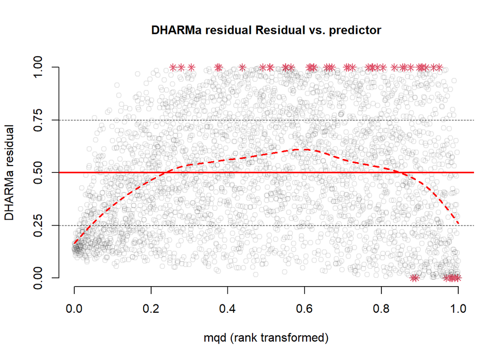

```r
res_mqd_linear <- simulateResiduals(m_mqd_linear)
res_mqd_quad <- simulateResiduals(m_mqd_quad)

plotResiduals(res_mqd_linear, form = dat_mqd$mqd)
```

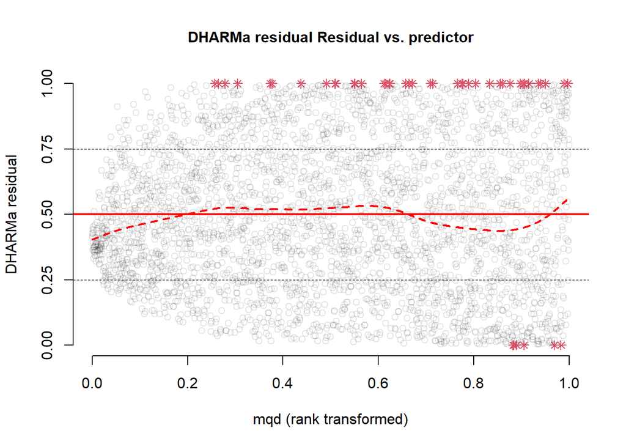

```r
plotResiduals(res_mqd_quad, form = dat_mqd$mqd)
```

The quadratic model removes much of the systematic curvature that remains in the residuals of the simple linear model.

We can also compare model fit using:

```r
AIC(m_mqd_linear, m_mqd_quad)
```

```
             df      AIC
m_mqd_linear  3 42265.63
m_mqd_quad    4 41811.34
```

```r
anova(m_mqd_linear, m_mqd_quad)
```

```
Analysis of Variance Table

Model 1: biomass ~ mqd
Model 2: biomass ~ mqd + I(mqd^2)
  Res.Df      RSS Df Sum of Sq     F    Pr(>F)
1   3408 48131357
2   3407 42103234  1   6028123 487.8 < 2.2e-16 ***
---
Signif. codes:  0 '***' 0.001 '**' 0.01 '*' 0.05 '.' 0.1 ' ' 1
```

A substantially lower AIC and a significant comparison support the quadratic model over the simple linear model.

A variable transformation could also be considered, but a quadratic polynomial is particularly convenient here because the relationship is explicitly hump-shaped: it can increase initially and then decrease.

### 8.2 2. Plot the selected model

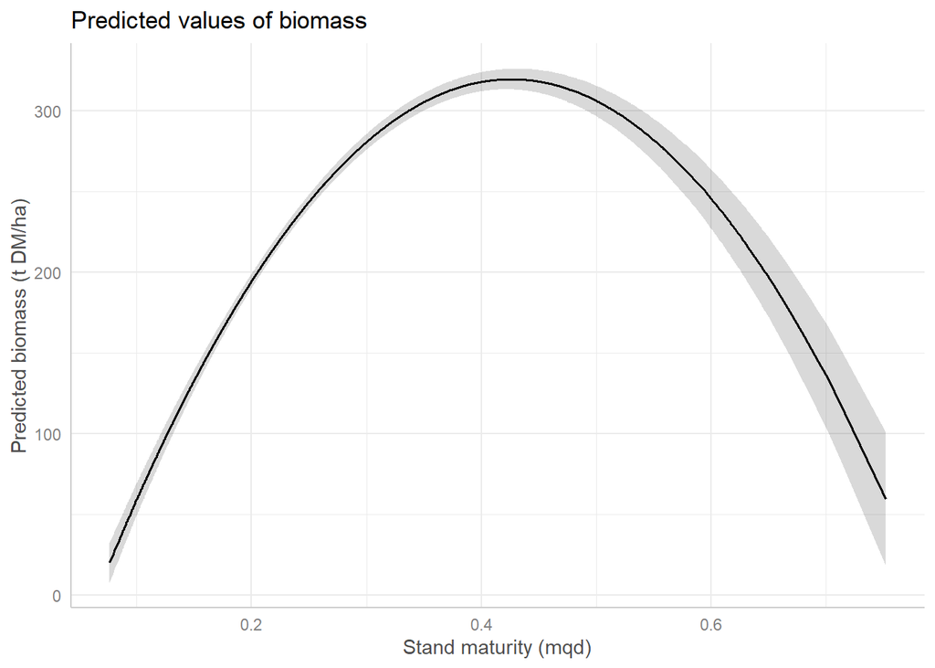

```r
pred_mqd_quad <- predict_response(
  m_mqd_quad,
  terms = "mqd"
)

plot(pred_mqd_quad) +
  labs(
    x = "Stand maturity (mqd)",
    y = "Predicted biomass (t DM/ha)"
  )
```

The fitted curve rises with `mqd`, reaches a maximum, and then decreases, producing the expected hump-shaped relationship.

### 8.3 3. Allow the non-linear relationship to vary with ownership

To investigate whether the quadratic relationship differs among ownership classes, we first standardise `mqd`.

```r
dat_mqd$ownership <- factor(
  dat_mqd$ownership,
  levels = c(
    "Autres forêts publiques RF",
    "Forêts domaniales RF",
    "Forêts privées et autres - En PSG",
    "Forêts privées et autres - Hors PSG"
  )
)

dat_mqd$mqd_scaled <- as.numeric(
  scale(dat_mqd$mqd)
)
```

We can then include interactions between ownership and both polynomial terms:

```r
m_mqd_ownership <- lm(
  biomass ~ (mqd_scaled + I(mqd_scaled^2)) * ownership,
  data = dat_mqd
)

summary(m_mqd_ownership)
```

```
Call:
lm(formula = biomass ~ (mqd_scaled + I(mqd_scaled^2)) * ownership,
    data = dat_mqd)

Residuals:
    Min      1Q  Median      3Q     Max
-314.79  -67.09   -5.61   61.24  798.83

Coefficients:
                                                             Estimate
(Intercept)                                                   261.346
mqd_scaled                                                     79.837
I(mqd_scaled^2)                                               -27.374
ownershipForêts domaniales RF                                 -14.596
ownershipForêts privées et autres - En PSG                    -15.959
ownershipForêts privées et autres - Hors PSG                   38.914
mqd_scaled:ownershipForêts domaniales RF                       -2.989
mqd_scaled:ownershipForêts privées et autres - En PSG           8.011
mqd_scaled:ownershipForêts privées et autres - Hors PSG        10.571
I(mqd_scaled^2):ownershipForêts domaniales RF                   1.758
I(mqd_scaled^2):ownershipForêts privées et autres - En PSG      3.372
I(mqd_scaled^2):ownershipForêts privées et autres - Hors PSG  -29.493
                                                             Std. Error t value
(Intercept)                                                       3.669  71.230
mqd_scaled                                                        3.683  21.679
I(mqd_scaled^2)                                                   2.166 -12.635
ownershipForêts domaniales RF                                     5.606  -2.604
ownershipForêts privées et autres - En PSG                        8.373  -1.906
ownershipForêts privées et autres - Hors PSG                      6.423   6.059
mqd_scaled:ownershipForêts domaniales RF                          5.318  -0.562
mqd_scaled:ownershipForêts privées et autres - En PSG             8.529   0.939
mqd_scaled:ownershipForêts privées et autres - Hors PSG           6.074   1.740
I(mqd_scaled^2):ownershipForêts domaniales RF                     3.159   0.556
I(mqd_scaled^2):ownershipForêts privées et autres - En PSG        4.855   0.695
I(mqd_scaled^2):ownershipForêts privées et autres - Hors PSG      4.791  -6.156
                                                             Pr(>|t|)
(Intercept)                                                   < 2e-16 ***
mqd_scaled                                                    < 2e-16 ***
I(mqd_scaled^2)                                               < 2e-16 ***
ownershipForêts domaniales RF                                 0.00926 **
ownershipForêts privées et autres - En PSG                    0.05673 .
ownershipForêts privées et autres - Hors PSG                 1.52e-09 ***
mqd_scaled:ownershipForêts domaniales RF                      0.57414
mqd_scaled:ownershipForêts privées et autres - En PSG         0.34767
mqd_scaled:ownershipForêts privées et autres - Hors PSG       0.08190 .
I(mqd_scaled^2):ownershipForêts domaniales RF                 0.57799
I(mqd_scaled^2):ownershipForêts privées et autres - En PSG    0.48737
I(mqd_scaled^2):ownershipForêts privées et autres - Hors PSG 8.33e-10 ***
---
Signif. codes:  0 '***' 0.001 '**' 0.01 '*' 0.05 '.' 0.1 ' ' 1

Residual standard error: 110 on 3398 degrees of freedom
Multiple R-squared:  0.3143,    Adjusted R-squared:  0.3121
F-statistic: 141.6 on 11 and 3398 DF,  p-value: < 2.2e-16
```

This is equivalent to allowing both the linear component and the curvature of the relationship to vary among ownership classes.

### 8.4 4. Plot the regression lines

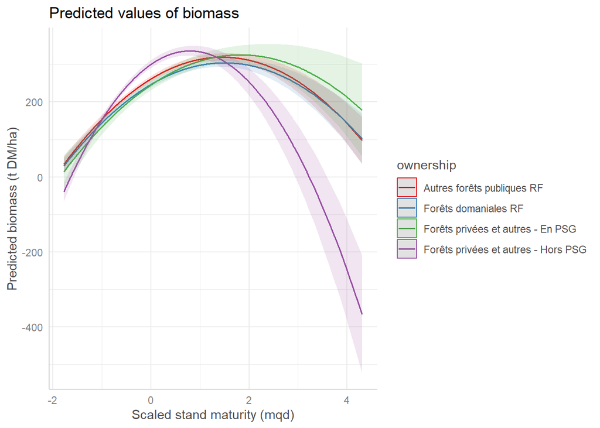

```r
pred_mqd_ownership <- predict_response(
  m_mqd_ownership,
  terms = c("mqd_scaled", "ownership")
)

plot(pred_mqd_ownership) +
  labs(
    x = "Scaled stand maturity (mqd)",
    y = "Predicted biomass (t DM/ha)"
  )
```

The resulting curves can look unusual, particularly near the edges of the predictor range.

This is a common danger when fitting interactions involving polynomial terms: each ownership class is given its own quadratic curve, and the model can therefore predict very different behaviour where there are few or no observations.

The most important point is that **we should not interpret predictions outside the range of the data for a given ownership class** -> linear model have poor extrapolation capacities.

We can check the range of `mqd` within each ownership class:

```r
dat_mqd %>%
  group_by(ownership) %>%
  summarise(
    n = n(),
    min_mqd = min(mqd),
    max_mqd = max(mqd)
  )
```

```
# A tibble: 4 × 4
  ownership                               n min_mqd max_mqd
  <fct>                               <int>   <dbl>   <dbl>
1 Autres forêts publiques RF           1300  0.0811   0.752
2 Forêts domaniales RF                 1034  0.0813   0.692
3 Forêts privées et autres - En PSG     299  0.0844   0.714
4 Forêts privées et autres - Hors PSG   777  0.0764   0.563
```

### 8.5 How can we remedy this?

A first remedy is to restrict predictions to the range of `mqd` that is actually observed within each ownership class rather than extrapolating the quadratic curves beyond the data.

It is also useful to display the observations together with the fitted curves:

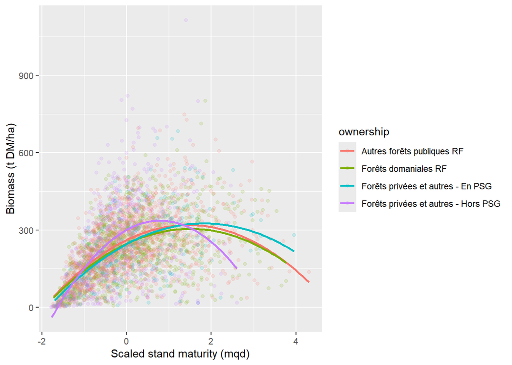

```r
ggplot(dat_mqd, aes(x = mqd_scaled, y = biomass, colour = ownership)) +
  geom_point(alpha = 0.15) +
  geom_smooth(
    method = "lm",
    formula = y ~ x + I(x^2),
    se = FALSE
  ) +
  labs(
    x = "Scaled stand maturity (mqd)",
    y = "Biomass (t DM/ha)"
  )
```

This makes it much easier to distinguish a genuine pattern supported by observations from a model-driven extrapolation.

More generally, when fitting complex interactions, we should always ask:

- Do we have data across the predictor gradient for every group?
- Are some predictions extrapolations?
- Is the additional complexity ecologically justified?
- Does the more complex model substantially improve the description of the data?

## 9 Summary

This practical illustrates three important extensions of the simple linear model.

### 9.1 Multiple covariates

Adding several predictors allows us to estimate the association between one predictor and the response while controlling for the others.

### 9.2 Interactions

Interactions allow the effect of one predictor to depend on another predictor. Graphically, interactions produce regression lines with different slopes rather than necessarily parallel lines.

### 9.3 Transformations and polynomials

A linear model does not necessarily imply a straight-line relationship with the original predictor. Transformations such as `log(x)` and polynomial terms such as `x + x^2` allow us to describe curved relationships while retaining the linear-model framework.

Finally, increasingly complex models require increasingly careful checking of their predictions. In particular, interactions and polynomial terms can produce apparently plausible curves in regions where there are little or no observations, so **extrapolation should always be checked explicitly** - this applies also to other model types than regression models such as machine learning models.